# 3월 24일 숙제

2018.3.24

# 1 library 불러오기

에러가 나면 tools - package install 하세요.

```r
library(ggplot2)
library(scales)
library(Hmisc)
library(data.table)
```

# 2 자료 불러오기

빗자루로 메모리 청소. 앞에서 RData 형식으로 저장한 파일을 불러온다.

```r
load(file="C:/Users/Home/Desktop/dt8.RData")
```

dt8 자료의 변수가 의미하는 바는 다음과 같다.

V1 가구번호  
V2 조사년도  
V3 조사부문  
V4 가구주성별  
V5 가구주만나이  
V6 가구주동거여부  
V7 가구주교육정도_학교  
V8 가구주교육정도_수료여부  
V9 가구주혼인상태  
V10 가구주종사상지위  
V11 가구주산업  
V12 가구주직업  
V13 가구원수  
V14 가구유형  
V15 현재살고있는주택의종류  
V16 전용면적  
V17 현재살고있는주택의입주형태  
V18 자산총액  
V19 금융자산  
V20 저축액  
V21 적립식저축  
V22 예치식저축  
V23 기타저축  
V24 현거주지전월세보증금  
V25 실물자산  
V26 부동산  
V27 거주주택  
V28 거주주택이외부동산  
V29 계약금및중도금납입액  
V30 기타실물자산  
V31 자동차  
V32 자동차이외  
V33 부채총액  
V34 금융부채  
V35 담보대출  
V36 부동산담보대출  
V37 거주주택담보대출  
V38 신용대출  
V39 신용카드관련대출  
V40 외상및할부미상환액  
V41 곗탄후불입금액  
V42 임대보증금  
V43 순자산액  
V44 경상소득  
V45 근로소득  
V46 사업소득  
V47 재산소득  
V48 이전소득  
V49 공적이전소득  
V50 사적이전소득  
V51 가처분소득  
V52 균등화가처분소득_분배  
V53 비소비지출  
V54 세금및과징금  
V55 공적연금및사회보험료  
V56 가구간이전  
V57 비영리단체이전  
V58 연간지급이자  
V59 연간상환액  
V60 연간지급이자및상환액  
V61 담보대출용도별(담보_대출잔액)  
V62 거주주택마련(담보_대출잔액)  
V63 거주주택이외부동산마련(담보_대출잔액)  
V64 전(월)세보증금마련(담보_대출잔액)  
V65 증권투자금마련(담보_대출잔액)  
V66 부채상환(담보_대출잔액)  
V67 사업자금(영농자금포함)마련(담보_대출잔액)  
V68 결혼자금마련(담보_대출잔액)  
V69 의료비마련(담보_대출잔액)  
V70 교육비마련(담보_대출잔액)  
V71 생활비마련(담보_대출잔액)  
V72 기타용도(담보_대출잔액)  
V73 담보형태(담보_대출잔액)  
V74 거주주택담보(담보_대출잔액)  
V75 거주주택이외부동산담보(담보_대출잔액)  
V76 예금,적금,보험담보(담보_대출잔액)  
V77 기타담보형태(담보_대출잔액)  
V78 신용대출용도(신용_대출잔액)  
V79 거주주택마련(신용_대출잔액)  
V80 거주주택이외부동산마련(신용_대출잔액)  
V81 전(월)세보증금마련(신용_대출잔액)  
V82 증권투자금마련(신용_대출잔액)  
V83 부채상환(신용_대출잔액)  
V84 사업자금마련(신용_대출잔액)  
V85 결혼자금마련(신용_대출잔액)  
V86 의료비마련(신용_대출잔액)  
V87 교육비마련(신용_대출잔액)  
V88 생활비마련(신용_대출잔액)  
V89 기타용도(신용_대출잔액)  
V90 부채보유여부  
V91 수도권여부  
V92 한부모가구  
V93 조손가구  
V94 노인가구  
V95 가구주연령10세계층  
V96 소득5분위  
V97 자산총액5분위  
V98 순자산액5분위  
V99 소득계층구간별  
V100 입주형태통합별  
V101 가구주종사상지위  
V102 가구주종사상지위(보도용)  
V103 가구주교육정도통합별  
V104 가중치

코드 값이 뜻하는 바는 엑셀 파일에 있다.

# 3 문제 1

부채총액과 실물자산의 산포도를 그리시오.

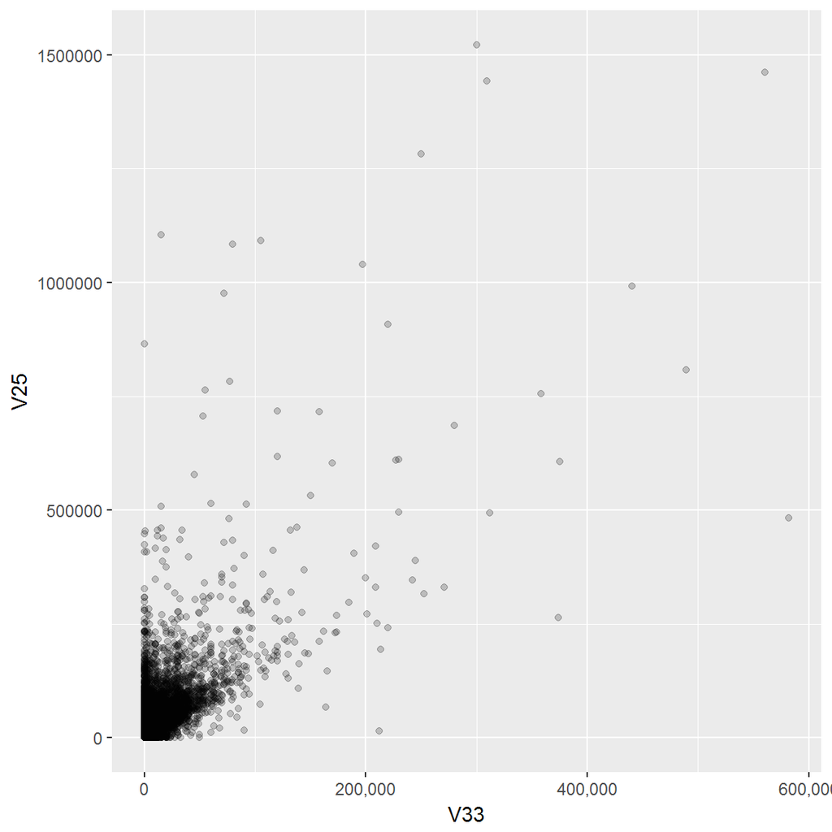

```r
ggplot(dt8, aes(x=V33,y=V25))+geom_point(alpha=0.2)+scale_x_continuous(labels = comma)
```

# 4 문제 2

가구주 연령10계층에 따라서 소득5분위 몇 명이나 있는지 적절한 막대 그래프로 그려 보시오.

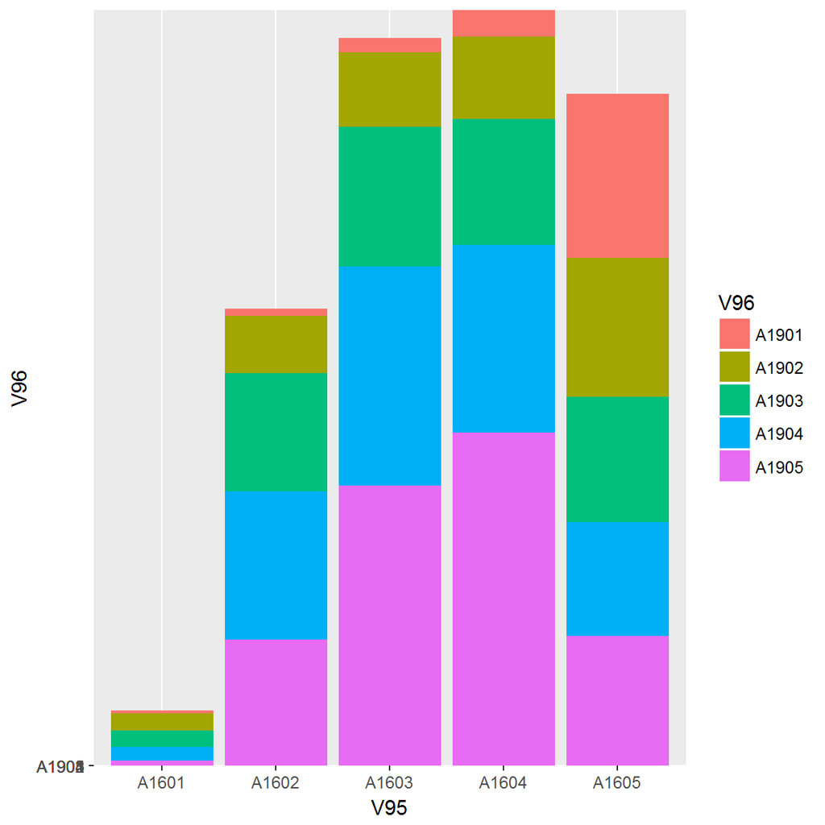

```r
ggplot(dt8,aes(x=V95,y=V96,fill=V96))+geom_bar(stat = 'identity')
```

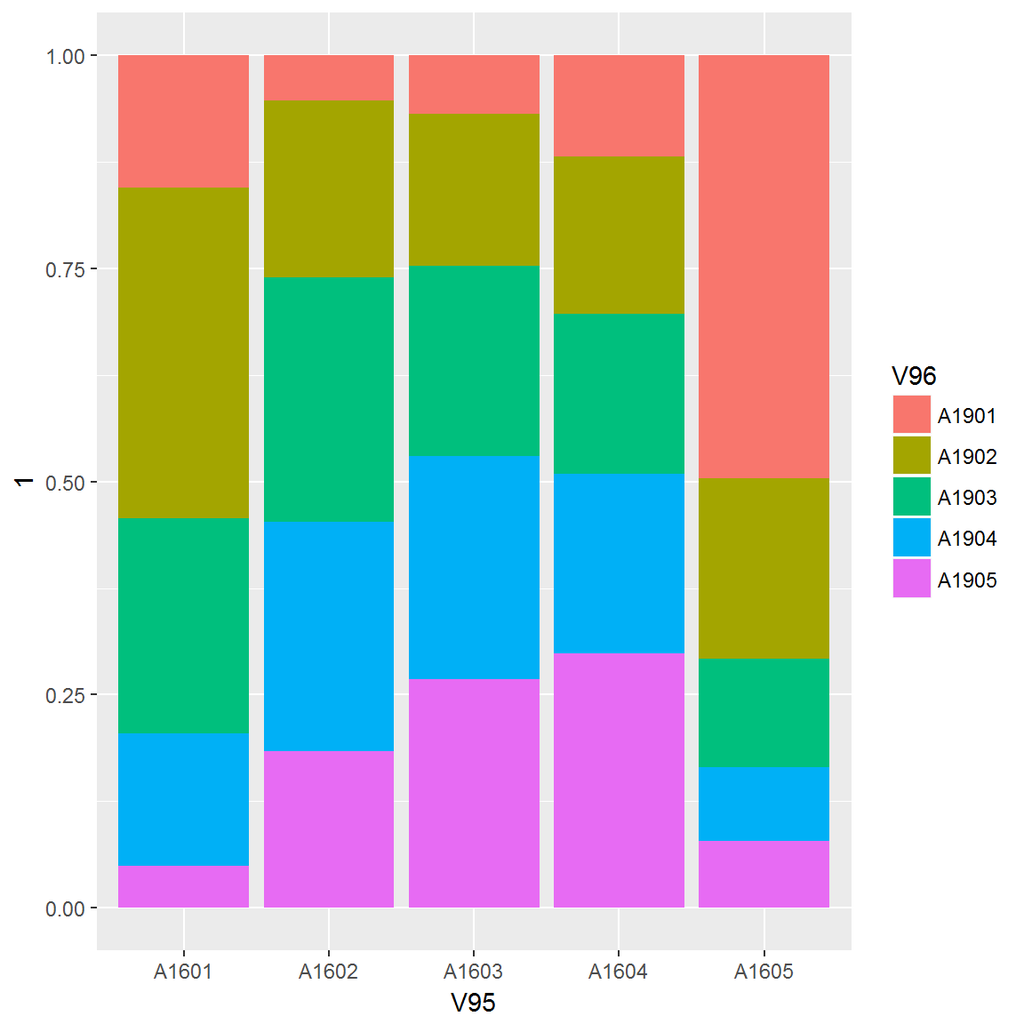

```r
ggplot(dt8,aes(x=V95,y=1,fill=V96))+geom_bar(stat = 'identity',position = "fill")
```

# 5 문제 3

가구주 성별로 평균 경상소득을 구하고, 막대 그래프로 그리시오.

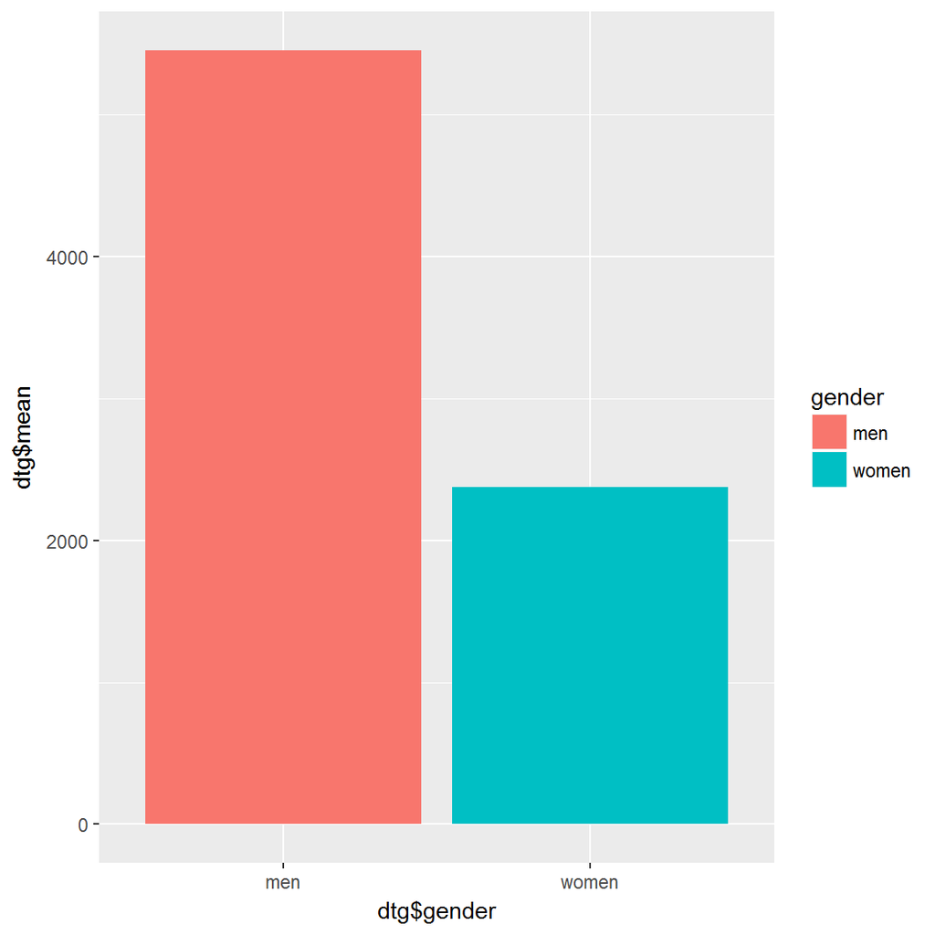

```r
male=dt8[dt8$V4==1,]
female=dt8[dt8$V4==2,]
mean=c(mean(male$V44),mean(female$V44))
gender=c('men', 'women')
dtg=data.frame(gender,mean)
ggplot(dtg)+geom_bar(aes(x=dtg$gender,y=dtg$mean,fill=gender),stat="identity")
```

# 6 문제 4

신용대출 용도별로 평균 대출잔액을 구하고, 막대 그래프로 그리시오.

```r
# V78 신용대출용도(신용_대출잔액)

# V79 거주주택마련(신용_대출잔액)
mean(dt8$V79)
```

```
## [1] 78.09588
```

```r
# V80 거주주택이외부동산마련(신용_대출잔액)
mean(dt8$V80)
```

```
## [1] 76.60663
```

```r
# V81 전(월)세보증금마련(신용_대출잔액)
mean(dt8$V81)
```

```
## [1] 49.91851
```

```r
# V82 증권투자금마련(신용_대출잔액)
mean(dt8$V82)
```

```
## [1] 10.55711
```

```r
# V83 부채상환(신용_대출잔액)
mean(dt8$V83)
```

```
## [1] 30.40256
```

```r
# V84 사업자금마련(신용_대출잔액)
mean(dt8$V84)
```

```
## [1] 218.3322
```

```r
# V85 결혼자금마련(신용_대출잔액)
mean(dt8$V85)
```

```
## [1] 5.049527
```

```r
# V86 의료비마련(신용_대출잔액)
mean(dt8$V86)
```

```
## [1] 4.313851
```

```r
# V87 교육비마련(신용_대출잔액)
mean(dt8$V87)
```

```
## [1] 28.94029
```

```r
# V88 생활비마련(신용_대출잔액)
mean(dt8$V88)
```

```
## [1] 132.3791
```

```r
# V89 기타용도(신용_대출잔액)
mean(dt8$V89)
```

```
## [1] 35.58606
```

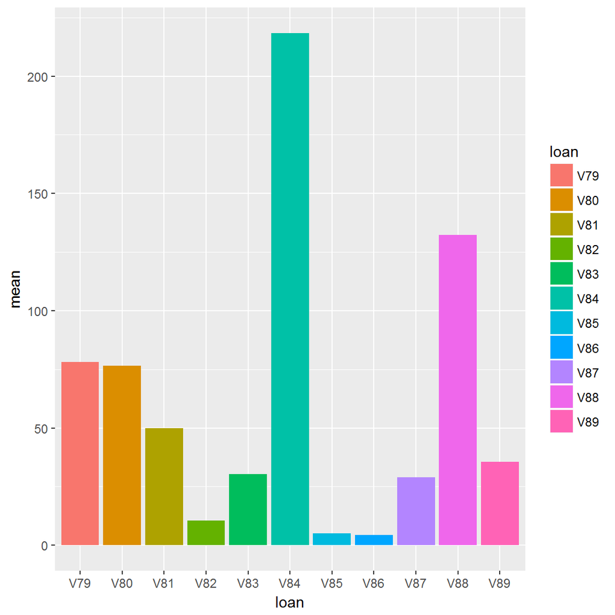

```r
mean=c(mean(dt8$V79),
mean(dt8$V80),
mean(dt8$V81),
mean(dt8$V82),
mean(dt8$V83),
mean(dt8$V84),
mean(dt8$V85),
mean(dt8$V86),
mean(dt8$V87),
mean(dt8$V88),
mean(dt8$V89))
loan=c('V79','V80','V81','V82','V83','V84','V85','V86','V87','V88','V89')

dtl=data.frame(loan,mean)
ggplot(dtl,aes(x=loan,y=mean,fill=loan))+geom_bar(stat = "identity")
```

# 7 문제 5

연구자가 관심 있는 변수 2개를 정해서 적절한 그래프로 그려 보시오.

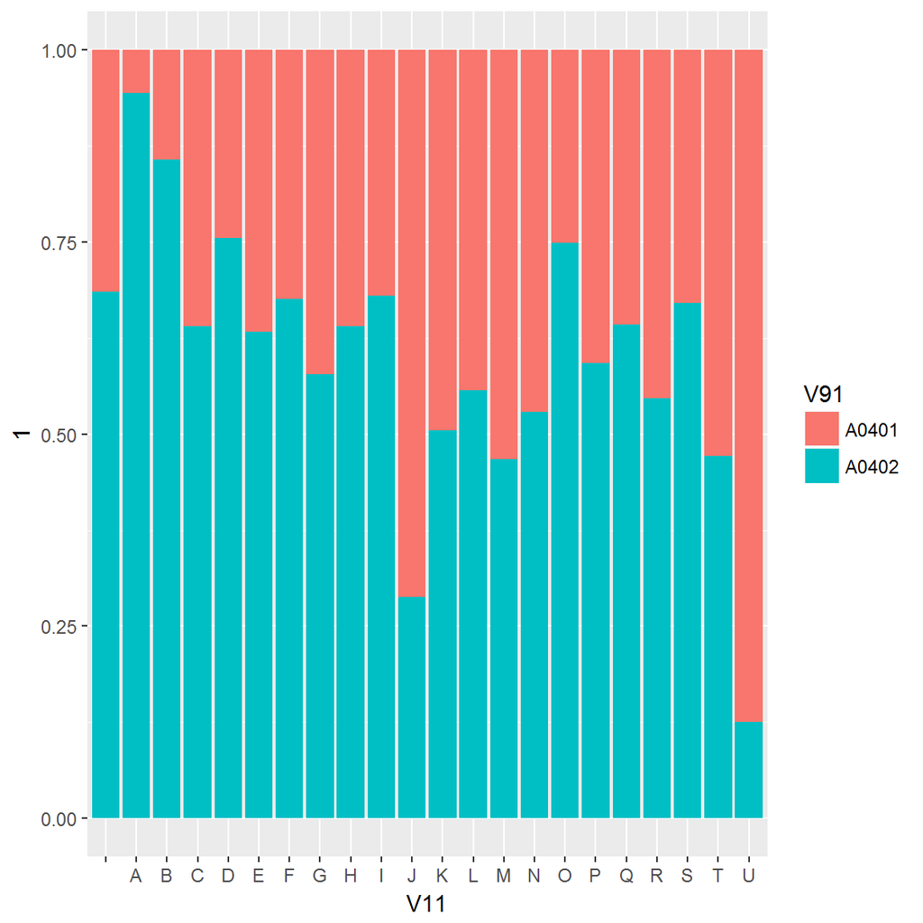

```r
ggplot(dt8,aes(x=V11,y=1,fill=V91))+geom_bar(stat = 'identity',position="fill")
```

```r
#수도권과 비수도권 지역간 산업구조의 차이가 어떤지 살펴보았습니다.
```